# Injury Detection in Cadet Basic Training

MAJ Dusty Turner

16 June 2020

# Authors

- MAJ Dusty Turner
- CDT Adam Hug
- CDT Christopher Ploch
- MAJ Bryan Adams
- COL Kevin Bigelman
- Dr Jason Suby
- COL Michael Scioletti
- Dr Diana M. Thomas

## Dusty Turner

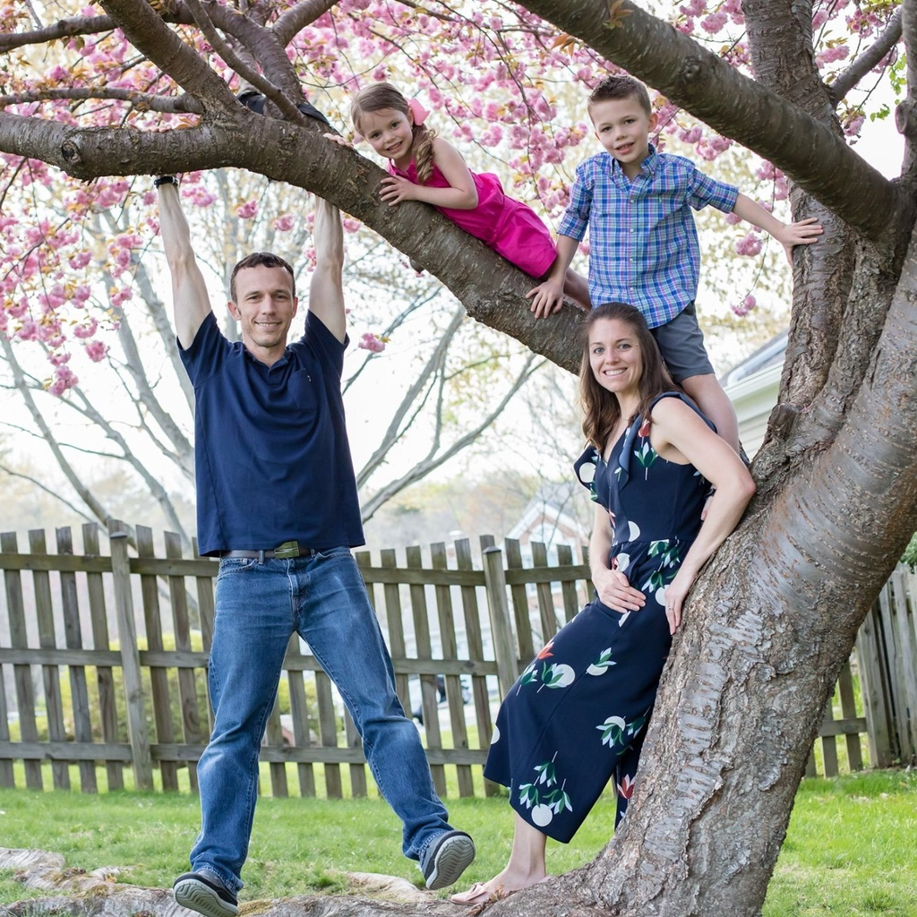

## Dusty Turner

- United States Military Academy at West Point ’07
  - BS: Operations Research
- Missouri University of Science and Technology ’12
  - MS: Engineering Management
- THE Ohio State University ’16
  - MS: Integrated Systems Engineering
  - Graduate Minor: Applied Statistics

## Dusty Turner

- Engineer Officer
  - Fort Leonard Wood, MO (BOLC / Sapper / Career Course)
  - Schofield Barracks, HI (Platoon Leader / XO / Staff)
  - White Sands Missile Range, HI (Staff / Company Command)
  - Iraq 08/09
  - Afghanistan 13
- ORSA
  - West Point, NY (Assistant Professor)
  - Fort Belvoir, VA (Center for Army Analysis)

Twitter [@dtdusty](https://twitter.com/dtdusty)  
My website [dustysturner.com](https://dustysturner.com/20200615_mors#/)  
This presentation dustysturner.com/20200615_mors

## What I Assume About You

- Health care familiarity
- Familiarity with statistics
- Appetite for the process
- Appreciate a few *dad* jokes

# Problem Specification

- Cadet Basic Training
  - West Point, NY
  - Over 1000 New Cadets
  - Wide range of fitness backgrounds
  - Pre-evaluated physically
- High levels of activity
  - 7 weeks of training
  - Rucking, running, etc
  - Uneven terrain
  - Sleep disruption
- Injuries to new trainees are costly to the military
  - Time
  - Money
  - Skill

#### Problem:

Many cadets often sustain lower body injuries during cadet basic training

#### Goal:

Identify which New Cadets are most likely to suffer a lower body injury during cadet basic training

#### Definition:

Injury determined as ‘required profile’ to miss training

## What do we know about this topic?

- High BMI and low BMI are indicators
- Fitness matters

#### Takeaway

Many false positives if we use a simple heuristic

### What does this study add?

A more analytical look at risk factors associated with lower body injuries in cadet basic training

# Data Exploration

```
## # A tibble: 12,899 x 17
##    usma_grad_yr gender ethnicity   age initial_hgt initial_wt pullups_raw
##           <dbl> <fct>  <fct>     <dbl>       <dbl>      <dbl>       <dbl>
##  1         2012 MALE   WHITE (C~    18          72        161          12
##  2         2012 FEMALE WHITE (C~    17          65        146           0
##  3         2012 MALE   WHITE (C~    22          73        206           7
##  4         2012 MALE   WHITE (C~    18          73        184          18
##  5         2012 MALE   WHITE (C~    18          70        177           9
##  6         2012 MALE   WHITE (C~    18          68        173          12
##  7         2012 MALE   WHITE (C~    19          74        283           3
##  8         2012 MALE   HISPANIC     18          66        151           8
##  9         2012 MALE   HISPANIC     18          66        151           8
## 10         2012 MALE   HISPANIC     17          67        158           8
## # ... with 12,889 more rows, and 10 more variables: fah_sec <dbl>,
## #   bbt_raw <dbl>, sr_raw <dbl>, crunch_raw <dbl>, pshups_raw <dbl>,
## #   cbt_initial_pushup <dbl>, cbt_initial_situp <dbl>, cbt_initial_run <dbl>,
## #   cbt_initial_swim <dbl>, injured <fct>
```

## Demographic Breakdown

Class Year

| usma_grad_yr | n |
| --- | --- |
| 2012 | 1330 |
| 2013 | 1359 |
| 2014 | 1411 |
| 2015 | 1294 |
| 2016 | 1203 |
| 2017 | 1209 |
| 2018 | 1237 |
| 2019 | 1265 |
| 2020 | 1327 |
| 2021 | 1264 |

Gender

| gender | n |
| --- | --- |
| FEMALE | 2573 |
| MALE | 10326 |

Age

[output not shown]

Injuries

| injured | n | prop |
| --- | --- | --- |
| 0 | 10187 | 0.7897511 |
| 1 | 2712 | 0.2102489 |

### Age and Gender Breakdown of New Cadets in the Study

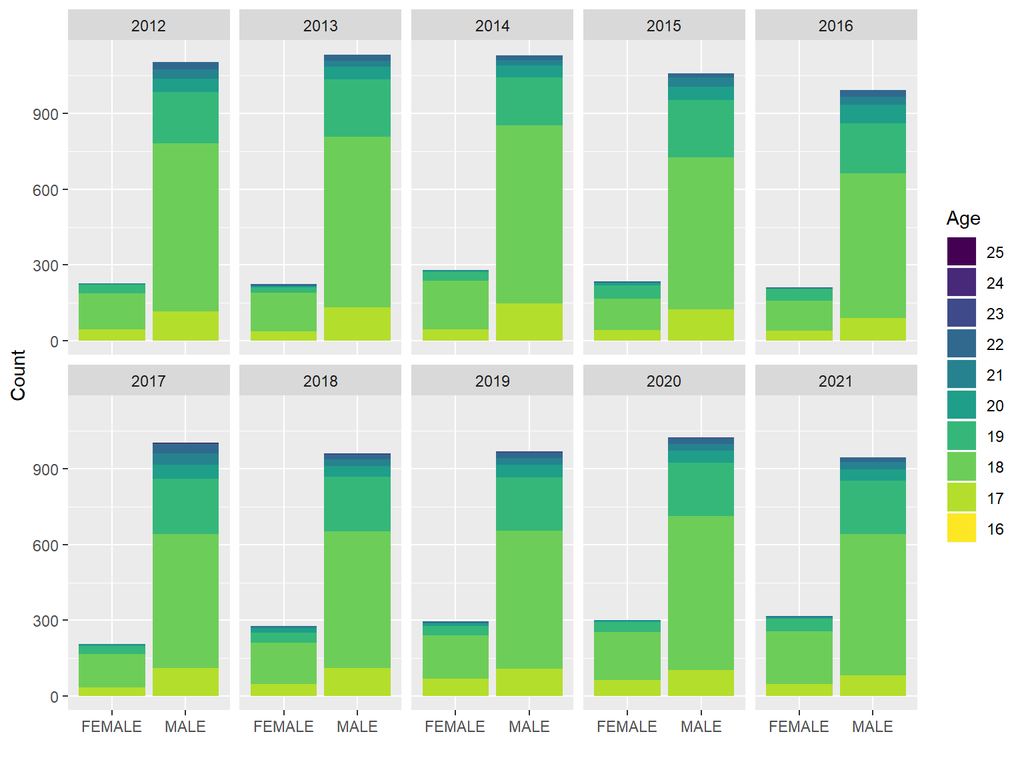

Distribution of Physical Measurements

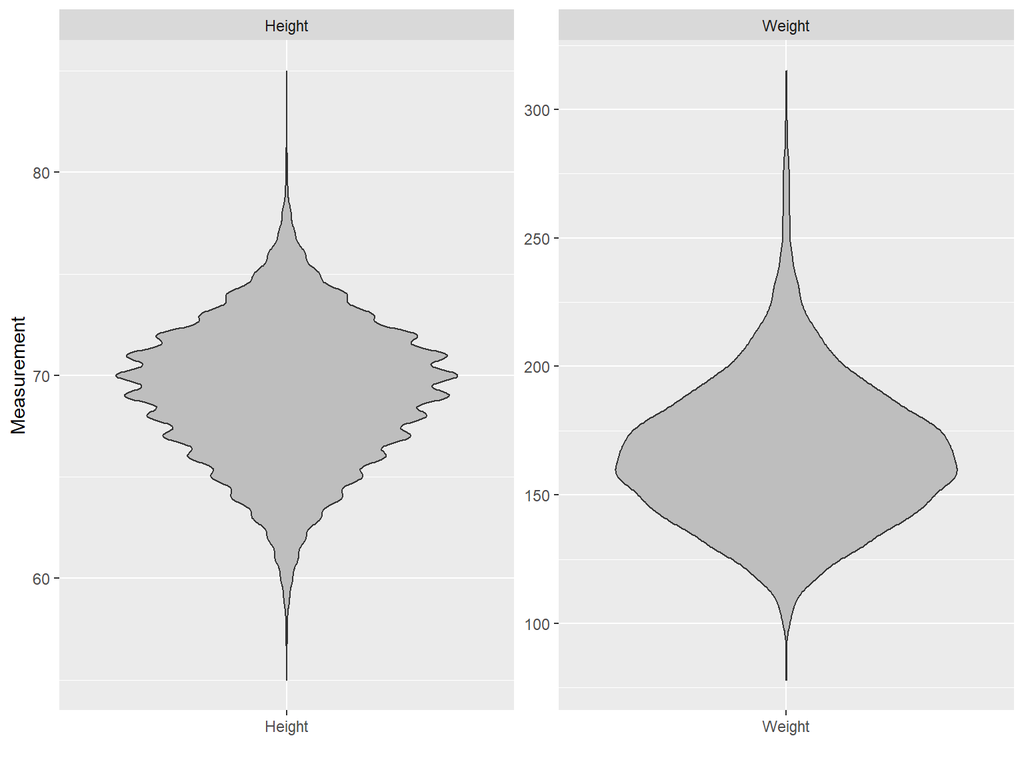

Distribution of Performance Data

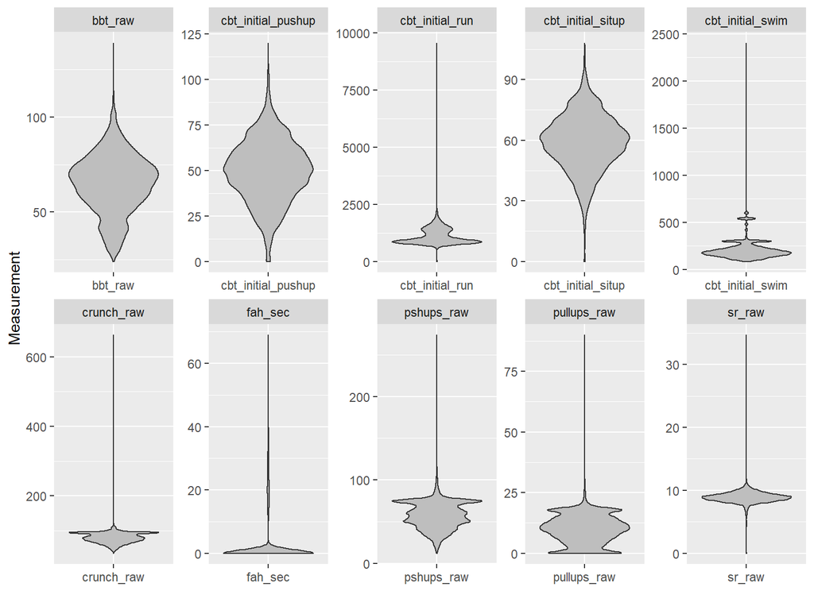

Demographics Vs Injuries

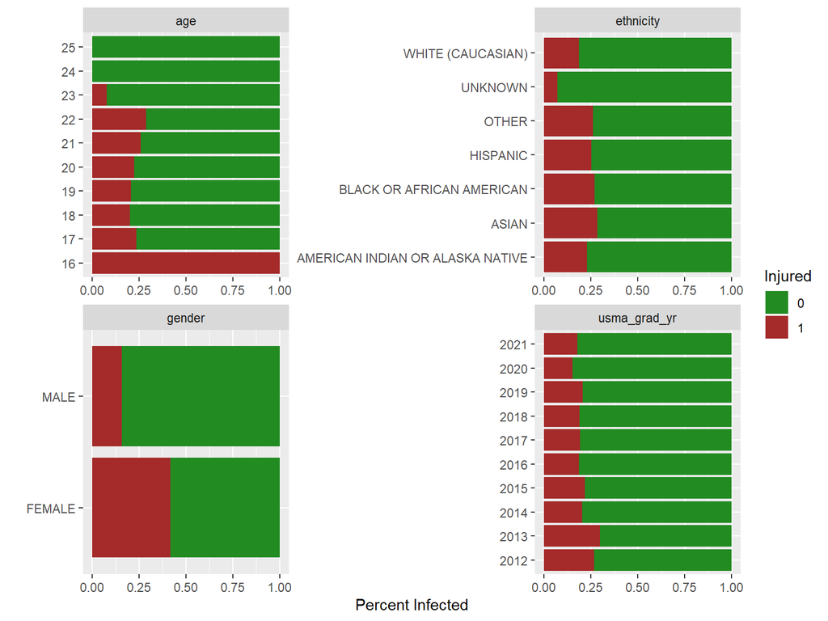

Demographics Vs Injuries

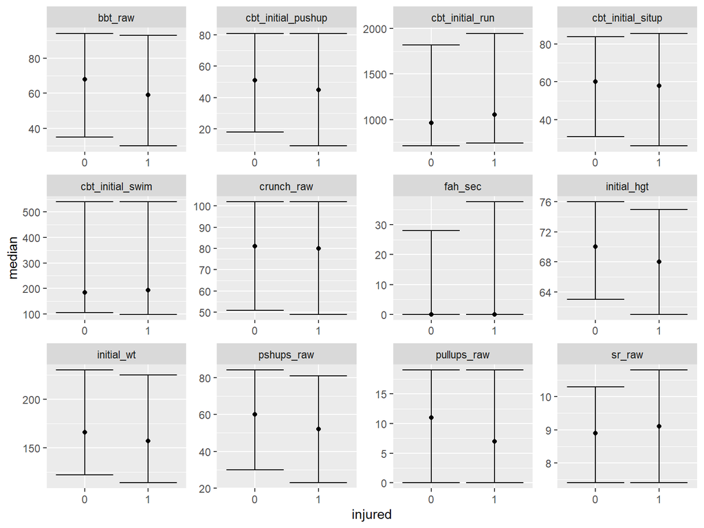

Demographics Vs Injuries

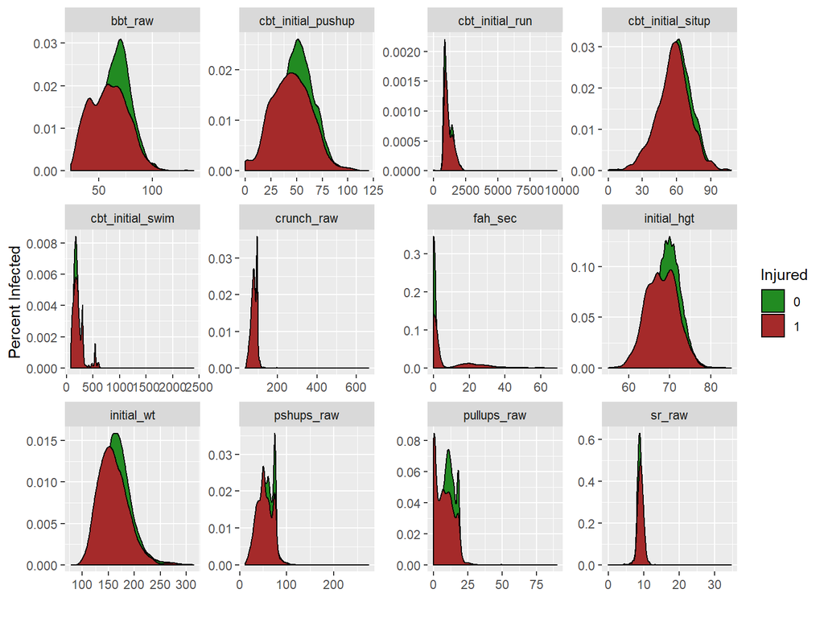

Missing Data

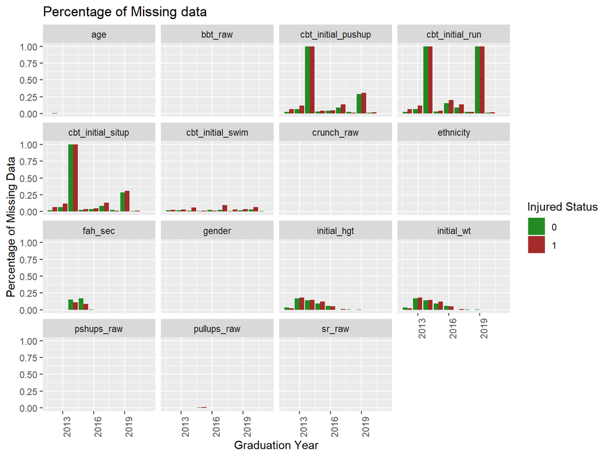

# Let’s Model

- Computer specifications
  - All modeling (and this presentation) in R
  - 32 GB RAM / 8 cores
- Model process
  - Use Tidymodels
  - Data processing
  - Cross validation
  - Run 3 models
    - Logistic regression
    - SVM
    - Random forest
  - Evaluate model

## Test/Train Split

```r
set.seed(6001)
initial_split <- initial_split(cbt, prop = 0.75)
initial_split
```

```
## <9675/3224/12899>
```

## Preprocess

```r
preprocessing_recipe <-
  recipe(injured ~ ., data = training(initial_split)) %>%
  step_rm(usma_grad_yr) %>%
  step_knnimpute(all_numeric()) %>%
  step_center(all_numeric()) %>%
  step_scale(all_numeric()) %>%
  step_lincomb(all_numeric()) %>%
  step_nzv(all_predictors()) %>%
  prep()
```

```
## # A tibble: 9,675 x 15
##    gender ethnicity    age initial_hgt initial_wt pullups_raw bbt_raw sr_raw
##    <fct>  <fct>      <dbl>       <dbl>      <dbl>       <dbl>   <dbl>  <dbl>
##  1 FEMALE WHITE (C~ -1.34      -1.24       -0.744      -1.69   -1.37   0.817
##  2 MALE   WHITE (C~  3.72       1.15        1.46       -0.492  -0.264  0.228
##  3 MALE   WHITE (C~ -0.329      1.15        0.651       1.39    0.191 -0.596
##  4 MALE   WHITE (C~ -0.329      0.250       0.394      -0.150   0.646 -0.243
##  5 MALE   WHITE (C~ -0.329     -0.346       0.247       0.362   0.126 -0.596
##  6 MALE   HISPANIC  -0.329     -0.943      -0.560      -0.321   0.451  0.228
##  7 MALE   HISPANIC  -0.329     -0.943      -0.560      -0.321   0.451  0.228
##  8 MALE   HISPANIC  -1.34      -0.644      -0.303      -0.321   0.711 -1.30
##  9 MALE   WHITE (C~ -0.329      0.549       0.174      -0.492  -0.654 -0.243
## 10 MALE   WHITE (C~  1.69      -0.0479      1.53       -0.321   0.646 -0.361
## # ... with 9,665 more rows, and 7 more variables: crunch_raw <dbl>,
## #   pshups_raw <dbl>, cbt_initial_pushup <dbl>, cbt_initial_situp <dbl>,
## #   cbt_initial_run <dbl>, cbt_initial_swim <dbl>, injured <fct>
```

## Set Up Cross Validation

```r
set.seed(nchar("beat_navy"))
cv_folds =
  training(initial_split) %>%
    bake(preprocessing_recipe, new_data = .) %>%
    vfold_cv(v = 5)
cv_folds
```

```
## #  5-fold cross-validation
## # A tibble: 5 x 2
##   splits              id
##   <named list>        <chr>
## 1 <split [7.7K/1.9K]> Fold1
## 2 <split [7.7K/1.9K]> Fold2
## 3 <split [7.7K/1.9K]> Fold3
## 4 <split [7.7K/1.9K]> Fold4
## 5 <split [7.7K/1.9K]> Fold5
```

## Specify Models

Regularized Logistic Regression

```r
glmnet_model =
  logistic_reg(mode = "classification",
    penalty = tune(),
    mixture = tune()) %>%
  set_engine("glmnet")
```

Support Vector Machine

```r
svm_model =
  svm_rbf(mode = "classification",
    cost = tune(),
    margin = tune()) %>%
  set_engine("kernlab")
```

Random Forest

```r
forest_model =
  rand_forest(
    mode = "classification",
    mtry = tune(),
    trees = tune(),
    min_n = tune()
  ) %>%
  set_engine("randomForest", objective = "reg:squarederror")
```

## Specify Tuning Parameters

Regularized Logistic Regression

```r
glmnet_params = parameters(penalty(), mixture())

set.seed(nchar("beat_navy"))

glmnet_grid <- grid_max_entropy(glmnet_params, size = 20)

glmnet_grid
```

```
## # A tibble: 20 x 2
##     penalty mixture
##       <dbl>   <dbl>
##  1 7.89e- 8 0.0212
##  2 7.54e- 4 0.459
##  3 1.76e-10 0.00555
##  4 1.21e-10 0.517
##  5 2.50e- 3 0.918
##  6 5.42e- 2 0.0886
##  7 3.73e-10 0.151
##  8 5.65e- 4 0.150
##  9 4.10e- 1 0.814
## 10 5.84e- 7 0.453
## 11 4.48e- 9 0.254
## 12 8.99e- 6 0.0665
## 13 1.40e-10 0.921
## 14 6.51e- 2 0.260
## 15 6.39e- 1 0.498
## 16 1.99e- 5 0.769
## 17 2.95e- 6 0.905
## 18 7.67e- 8 0.709
## 19 1.05e- 7 0.984
## 20 1.66e- 6 0.207
```

Regularized Logistic Regression

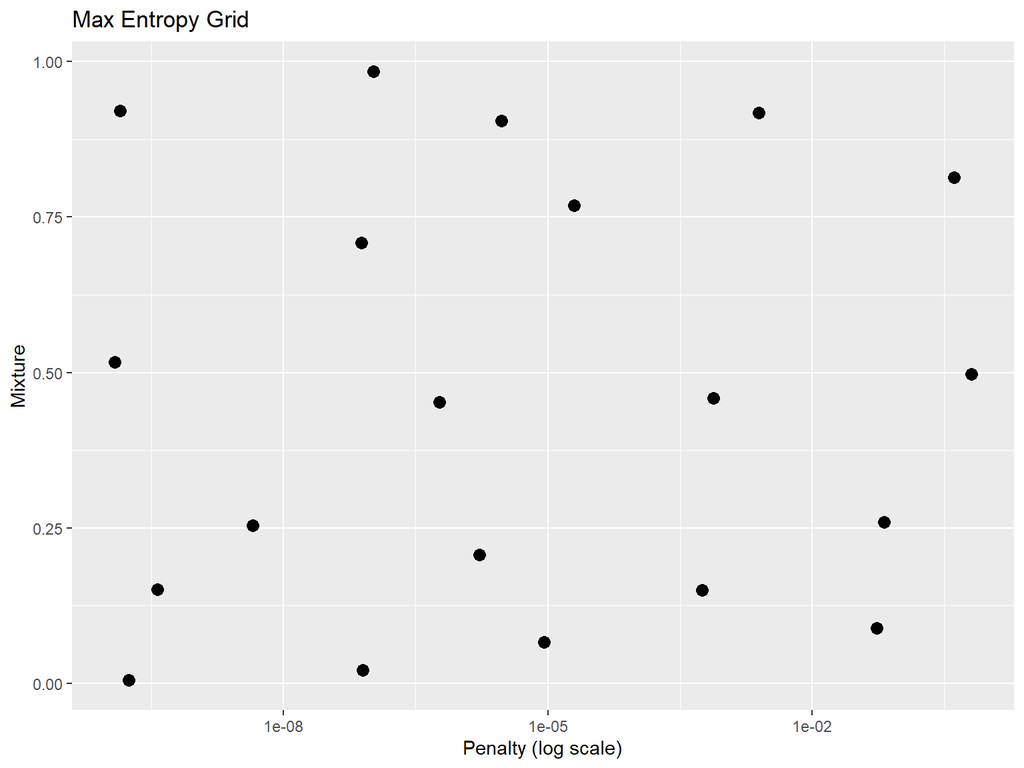

## Specify Tuning Parameters

Support Vector Machine

```r
svm_params <- parameters(cost(),margin())

set.seed(nchar("beat_navy"))

svm_grid <- grid_max_entropy(svm_params, size = 20)

svm_grid
```

```
## # A tibble: 20 x 2
##       cost  margin
##      <dbl>   <dbl>
##  1 0.00595 0.00424
##  2 0.0713  0.0918
##  3 0.00114 0.00111
##  4 0.00103 0.103
##  5 0.0986  0.184
##  6 0.227   0.0177
##  7 0.00140 0.0302
##  8 0.0659  0.0300
##  9 0.393   0.163
## 10 0.0102  0.0905
## 11 0.00274 0.0508
## 12 0.0215  0.0133
## 13 0.00107 0.184
## 14 0.239   0.0519
## 15 0.443   0.0995
## 16 0.0266  0.154
## 17 0.0159  0.181
## 18 0.00591 0.142
## 19 0.00644 0.197
## 20 0.0136  0.0415
```

Support Vector Machine

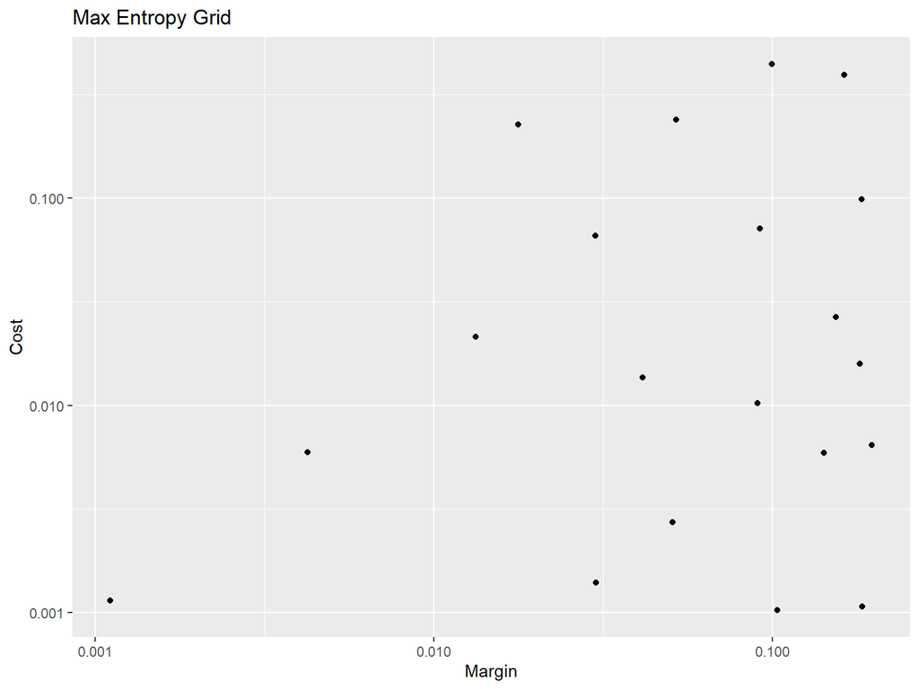

## Specify Tuning Parameters

Random Forest

```r
forest_params <- parameters(mtry(c(2,6)), trees(), min_n())

set.seed(nchar("beat_navy"))

forest_grid <- grid_max_entropy(forest_params, size = 30)

forest_grid
```

```
## # A tibble: 30 x 3
##     mtry trees min_n
##    <int> <int> <int>
##  1     3   509     5
##  2     5   824     9
##  3     4  1474    31
##  4     4   830    38
##  5     3   630    22
##  6     6  1539     5
##  7     3    10    32
##  8     5   156    21
##  9     2  1941    25
## 10     2   468    31
## # ... with 20 more rows
```

Random Forest

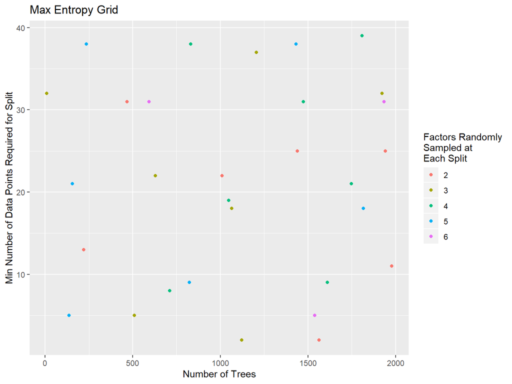

## Execute CV

Regularized Logistic Regression

```r
library(tune)
glmnet_stage_1_cv_results_tbl <- tune_grid(
    formula   = injured ~ .,
    model     = glmnet_model,
    resamples = cv_folds,
    grid      = glmnet_grid,
    metrics   = metric_set(accuracy, kap, roc_auc),
    control   = control_grid(verbose = TRUE)
)
```

Best Regularized Logistic Regression Models by Accuracy

| penalty | mixture | .metric | .estimator | mean | n | std_err |
| --- | --- | --- | --- | --- | --- | --- |
| 0.0025000 | 0.9175822 | accuracy | binary | 0.7901809 | 5 | 0.0032066 |
| 0.0651365 | 0.2596122 | accuracy | binary | 0.7897674 | 5 | 0.0031495 |
| 0.4102575 | 0.8139516 | accuracy | binary | 0.7897674 | 5 | 0.0031495 |
| 0.6392178 | 0.4977349 | accuracy | binary | 0.7897674 | 5 | 0.0031495 |
| 0.0000000 | 0.9214264 | accuracy | binary | 0.7895607 | 5 | 0.0040343 |

Best Regularized Logistic Regression Models by AUC

[output not shown]

## Execute CV

Support Vector Machine

```r
library(tune)
library(doFuture)

all_cores <- parallel::detectCores(logical = FALSE)

registerDoFuture()
cl <- makeCluster(all_cores)
plan(cluster, workers = cl)

svm_stage_1_cv_results_tbl <- tune_grid(
    formula   = injured ~ .,
    model     = svm_model,
    resamples = cv_folds,
    grid      = svm_grid,
    metrics   = metric_set(accuracy, kap, roc_auc),
    control   = control_grid(verbose = TRUE)
)
stopCluster(cl)
```

Best Support Vector Machine Models by Accuracy

| cost | margin | .metric | .estimator | mean | n | std_err |
| --- | --- | --- | --- | --- | --- | --- |
| 0.0010284 | 0.1033832 | accuracy | binary | 0.7897674 | 5 | 0.0031495 |
| 0.0010705 | 0.1842853 | accuracy | binary | 0.7897674 | 5 | 0.0031495 |
| 0.0011387 | 0.0011097 | accuracy | binary | 0.7897674 | 5 | 0.0031495 |
| 0.0013953 | 0.0301910 | accuracy | binary | 0.7897674 | 5 | 0.0031495 |
| 0.0027360 | 0.0507845 | accuracy | binary | 0.7897674 | 5 | 0.0031495 |

Best Support Vector Machine Models by AUC

| cost | margin | .metric | .estimator | mean | n | std_err |
| --- | --- | --- | --- | --- | --- | --- |
| 0.0135910 | 0.0414690 | roc_auc | binary | 0.6327265 | 5 | 0.0145927 |
| 0.0059515 | 0.0042356 | roc_auc | binary | 0.6327047 | 5 | 0.0148379 |
| 0.0102377 | 0.0905025 | roc_auc | binary | 0.6312202 | 5 | 0.0140461 |
| 0.0659241 | 0.0299808 | roc_auc | binary | 0.6308900 | 5 | 0.0150573 |
| 0.0214718 | 0.0132961 | roc_auc | binary | 0.6307495 | 5 | 0.0140065 |

## Execute CV

Random Forest

```r
library(tune)
library(doFuture)

all_cores <- parallel::detectCores(logical = FALSE)

registerDoFuture()
cl <- makeCluster(all_cores)
plan(cluster, workers = cl)

forest_stage_1_cv_results_tbl <- tune_grid(
    formula   = injured ~ .,
    model     = forest_model,
    resamples = cv_folds,
    grid      = forest_grid,
    metrics   = metric_set(accuracy, kap, roc_auc),
    control   = control_grid(verbose = TRUE)
)

stopCluster(cl)
```

Best Random Forest Models by Accuracy

| mtry | trees | min_n | .metric | .estimator | mean | n | std_err |
| --- | --- | --- | --- | --- | --- | --- | --- |
| 3 | 1122 | 2 | accuracy | binary | 0.8348320 | 5 | 0.0043991 |
| 6 | 1539 | 5 | accuracy | binary | 0.8340052 | 5 | 0.0045625 |
| 5 | 137 | 5 | accuracy | binary | 0.8318346 | 5 | 0.0042604 |
| 3 | 509 | 5 | accuracy | binary | 0.8248062 | 5 | 0.0044606 |
| 4 | 711 | 8 | accuracy | binary | 0.8222222 | 5 | 0.0043115 |

Best Random Forest Models by AUC

| mtry | trees | min_n | .metric | .estimator | mean | n | std_err |
| --- | --- | --- | --- | --- | --- | --- | --- |
| 3 | 1122 | 2 | roc_auc | binary | 0.7305338 | 5 | 0.0096590 |
| 3 | 509 | 5 | roc_auc | binary | 0.7278807 | 5 | 0.0090252 |
| 6 | 1539 | 5 | roc_auc | binary | 0.7263910 | 5 | 0.0098611 |
| 5 | 137 | 5 | roc_auc | binary | 0.7258140 | 5 | 0.0097862 |
| 4 | 711 | 8 | roc_auc | binary | 0.7252060 | 5 | 0.0096792 |

## Save Best Parameters

Regularized Logistic Regression

```
## Logistic Regression Model Specification (classification)
##
## Main Arguments:
##   penalty = 0.00250004478586627
##   mixture = 0.917582200141624
##
## Computational engine: glmnet
```

Support Vector Machine

```
## Radial Basis Function Support Vector Machine Specification (classification)
##
## Main Arguments:
##   cost = 0.0135909640998788
##   margin = 0.0414689703378826
##
## Computational engine: kernlab
```

Random Forest

```
## Random Forest Model Specification (classification)
##
## Main Arguments:
##   mtry = 3
##   trees = 1122
##   min_n = 2
##
## Engine-Specific Arguments:
##   objective = reg:squarederror
##
## Computational engine: randomForest
```

## Compare Models

| .metric | .estimate | mod |
| --- | --- | --- |
| accuracy | 0.8359181 | forest |
| accuracy | 0.7900124 | glmnet |
| accuracy | 0.7897022 | svm |
| kap | 0.3493245 | forest |
| kap | 0.0272451 | glmnet |
| kap | 0.0000000 | svm |

## ROC

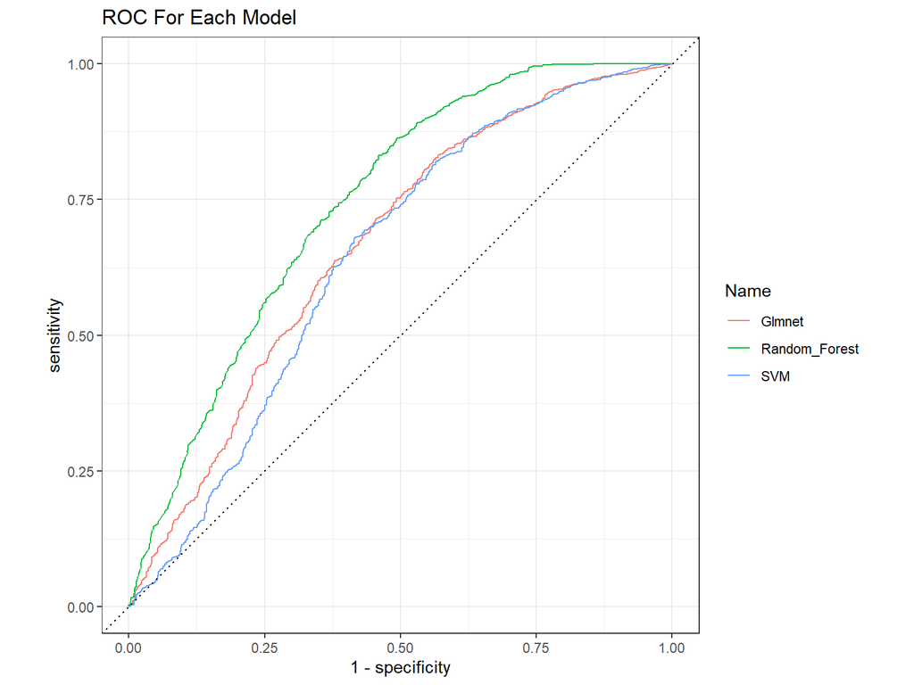

## Execute Best Model and Determine Accuracy Rate

|  | 0 | 1 |
| --- | --- | --- |
| 0 | 10077 | 110 |
| 1 | 1806 | 906 |

## Variable Importance

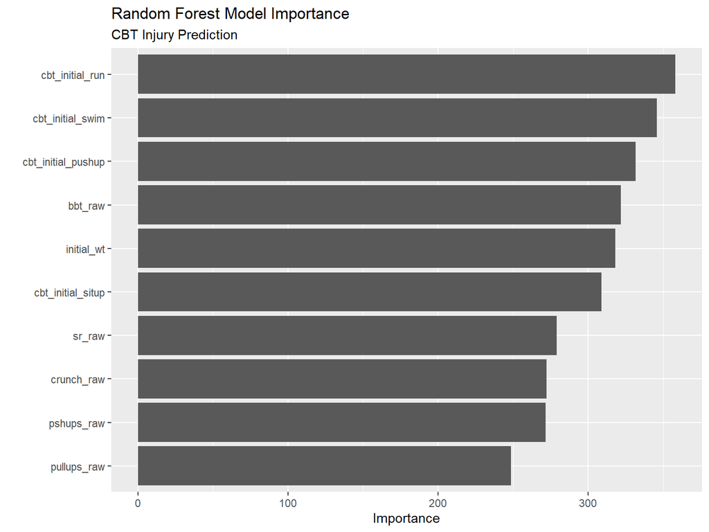

# Conclusions

- While injuries aren’t knowable, we can identify those at more risk
- Take special care of those who might need more injury prevention
- Must be careful about second order impacts of policies

# References

- Knapik JJ, Sharp MA, Steelman RA. Secular Trends in the Physical Fitness of United States Army Recruits on Entry to Service, 1975-2013. J Strength Cond Res. 2017;31(7):2030-52.
- Knapik JJ, Darakjy S, Hauret KG, Canada S, Scott S, Rieger W, et al. Increasing the physical fitness of low-fit recruits before basic combat training: an evaluation of fitness, injuries, and training outcomes. Mil Med. 2006;171(1):45-54.
- Knapik JJ. The importance of physical fitness for injury prevention: part 1. J Spec Oper Med. 2015;15(1):123-7.
- Max Kuhn and Hadley Wickham (2020). tidymodels: Easily Install and Load the ‘Tidymodels’ Packages. R package version 0.1.0. https://CRAN.R-project.org/package=tidymodels
- R Core Team (2019). R: A language and environment for statistical computing. R Foundation for Statistical Computing, Vienna, Austria. URL https://www.R-project.org/
- Wickham et al., (2019). Welcome to the tidyverse. Journal of Open Source Software, 4(43), 1686, https://doi.org/10.21105/joss.01686